# K-Nearest Neighbors Classification with Recursive Feature Elimination and Genetic Algorithm for Detecting Adulteration in Instant Coffee:MSC+SG+2nd Derivative Spectra

Author

Derick Malavi

## Introduction

Coffee adulteration, such as blending premium Arabica with lower-cost Robusta, undermines both quality and authenticity, posing significant challenges for consumers and regulators. High-dimensional spectroscopic data offers a wealth of information for detecting such adulteration, but the abundance of variables requires robust feature selection techniques to identify the most relevant wavelengths. Recursive Feature Elimination (RFE) and Genetic Algorithms (GA) are powerful tools for optimizing feature selection in spectroscopic datasets. This study integrates RFE and GA to enhance the performance of machine learning models in classifying pure and adulterated coffee. By leveraging these approaches, we aim to demonstrate an efficient and reliable method for detecting and quantifying coffee adulteration.

## Setup and Load Libraries

```r
# Load libraries
warning = FALSE
  suppressWarnings(suppressMessages({
  library(caret)
  library(GA)
  library(ggplot2)
  library(dplyr)
  library(readxl)
  library(readr)
  library(pls)
  library(janitor)
  library(class)
  library(MLmetrics)
  library(MLeval)
  library(themis)
  library(ROSE)
  library(parallel)
  library(doParallel)
  library(foreach)
  library(pheatmap)
  library(mdatools)
  library(nnet)
  library(DMwR)
  library(e1071)
  library(knitr)
  library(pROC)
  library(gridExtra)
  library(FactoMineR)
  library(doSNOW)
  library(MASS)
  library(factoextra)
  library(kernlab)}))
```

## Prepare Data

```r
# Load data: msc_sg_2d spectra

hsi_msc_sg_2d <- read.csv("coffee_instant_msc_sg_2d.csv")


# Ensure we have the same number of dimensions and the range of our columns
dim(hsi_msc_sg_2d)
```

```
[1] 1476  229
```

```r
# Check a few column names
col_check <- colnames(hsi_msc_sg_2d[,c(1:6)])
col_check
```

```
[1] "sample_name"  "binary_class" "three_class"  "cal_val"      "perc_adulter"
[6] "X935.609985"
```

```r
# The spectral values start from column # 6-------> 229

# Convert the class to a factor
hsi_msc_sg_2d$binary_class <- as.factor(hsi_msc_sg_2d$binary_class)
```

## Get the X and y variables

```r
X <- hsi_msc_sg_2d[,c(6:229)]
y <- hsi_msc_sg_2d[,2]

class(y) #Ensure y (target variable) is a factor for classification
```

```
[1] "factor"
```

## Visualize X

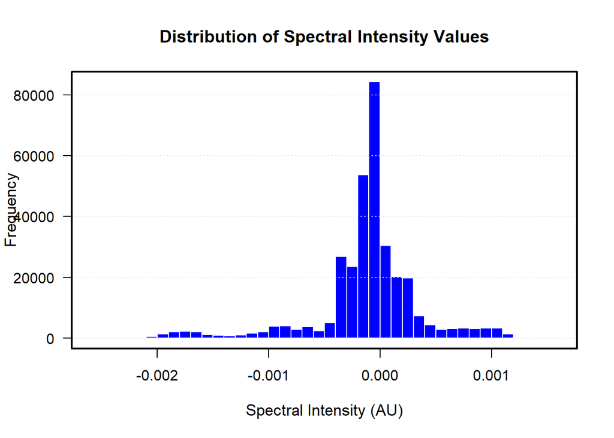

```r
# Create histogram of spectral intensities with improved formatting
hist(as.matrix(X),
     col = "blue",
     border = "white",
     main = "Distribution of Spectral Intensity Values",
     xlab = "Spectral Intensity (AU)",
     ylab = "Frequency",
     las = 1,
     cex.main = 1.2,
     cex.lab = 1.1,
     breaks = 30)

# Add grid lines
grid(nx = NA, ny = NULL, col = "gray90", lty = "dotted")

# Add box around plot
box(lwd = 2)
```